# week9 eda

2025-11-25

```r
data <- read.csv("/Users/blubb/Desktop/170 files/mergeddata.csv")

set.seed(58)    #seed 58
n <- nrow(data)
train_index <- sample(1:n, size = 0.7 * n)
train_data <- data[train_index, ]
test_data  <- data[-train_index, ]
```

**I realize that I messed up last weeks 1st order model so I am redoing it here first before I do this weeks higher order model.**

```r
#model 1
lastWeekMod1 <- lm(totalDisasters ~ PPM + aveMonthSeaTemp  + avg_surfacePressure+avg_saePressure+ Anomaly+ avg_cng_sealevel, data = train_data)
summary(lastWeekMod1)
```

```
##
## Call:
## lm(formula = totalDisasters ~ PPM + aveMonthSeaTemp + avg_surfacePressure +
##     avg_saePressure + Anomaly + avg_cng_sealevel, data = train_data)
##
## Residuals:
##     Min      1Q  Median      3Q     Max
## -24.610  -7.020  -0.913   6.112  33.971
##
## Coefficients:
##                       Estimate Std. Error t value Pr(>|t|)
## (Intercept)         -1.797e+03  1.036e+03  -1.733   0.0843 .
## PPM                  5.533e-02  7.498e-02   0.738   0.4613
## aveMonthSeaTemp      2.312e+01  3.695e+00   6.257 1.82e-09 ***
## avg_surfacePressure  2.125e-01  4.082e-02   5.204 4.21e-07 ***
## avg_saePressure     -1.886e-01  3.866e-02  -4.879 1.96e-06 ***
## Anomaly             -4.643e+00  2.249e+00  -2.064   0.0401 *
## avg_cng_sealevel    -3.628e-02  3.420e-02  -1.061   0.2898
## ---
## Signif. codes:  0 '***' 0.001 '**' 0.01 '*' 0.05 '.' 0.1 ' ' 1
##
## Residual standard error: 10.52 on 237 degrees of freedom
## Multiple R-squared:  0.1857, Adjusted R-squared:  0.1651
## F-statistic: 9.009 on 6 and 237 DF,  p-value: 7.14e-09
```

```r
car::vif(lastWeekMod1)
```

```
##                 PPM     aveMonthSeaTemp avg_surfacePressure     avg_saePressure
##            3.810622            1.683985           19.308211           20.729259
##             Anomaly    avg_cng_sealevel
##            2.181840            3.336576
```

```r
#model 2
lastWeekMod2 <- lm(totalDisasters ~ PPM + aveMonthSeaTemp  + avg_surfacePressure+ Anomaly+ avg_cng_sealevel, data = train_data)
summary(lastWeekMod2)
```

```
##
## Call:
## lm(formula = totalDisasters ~ PPM + aveMonthSeaTemp + avg_surfacePressure +
##     Anomaly + avg_cng_sealevel, data = train_data)
##
## Residuals:
##     Min      1Q  Median      3Q     Max
## -29.774  -7.968  -1.433   5.812  34.778
##
## Coefficients:
##                       Estimate Std. Error t value Pr(>|t|)
## (Intercept)         -2.128e+03  1.083e+03  -1.966   0.0505 .
## PPM                 -2.789e-02  7.643e-02  -0.365   0.7155
## aveMonthSeaTemp      1.585e+01  3.540e+00   4.478 1.17e-05 ***
## avg_surfacePressure  2.020e-02  1.115e-02   1.811   0.0714 .
## Anomaly             -3.194e+00  2.334e+00  -1.368   0.1725
## avg_cng_sealevel     4.533e-02  3.123e-02   1.452   0.1479
## ---
## Signif. codes:  0 '***' 0.001 '**' 0.01 '*' 0.05 '.' 0.1 ' ' 1
##
## Residual standard error: 11.01 on 238 degrees of freedom
## Multiple R-squared:  0.1039, Adjusted R-squared:  0.08511
## F-statistic: 5.521 on 5 and 238 DF,  p-value: 7.869e-05
```

```r
car::vif(lastWeekMod2)
```

```
##                 PPM     aveMonthSeaTemp avg_surfacePressure             Anomaly
##            3.613430            1.410367            1.315451            2.143800
##    avg_cng_sealevel
##            2.538310
```

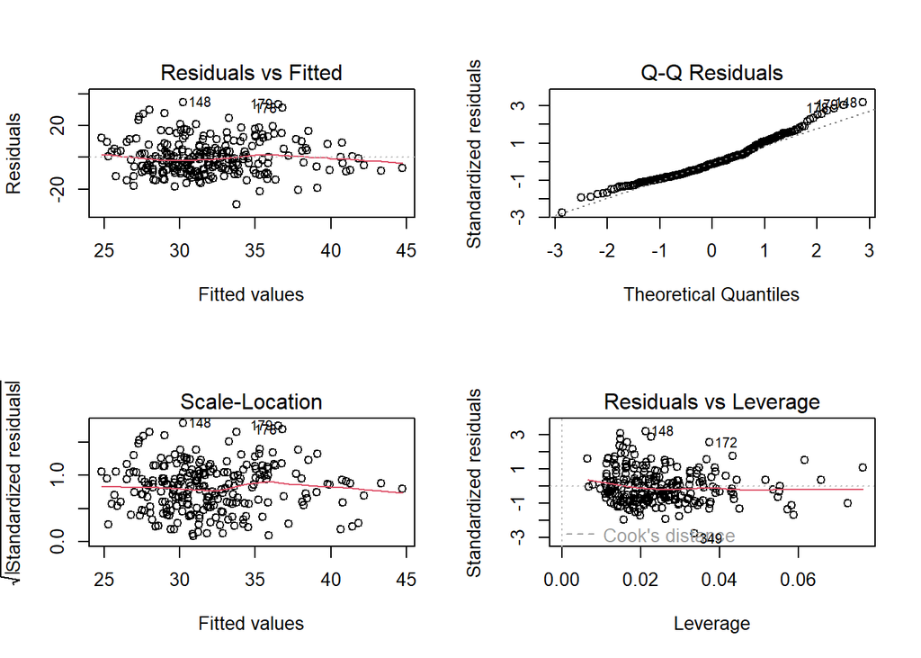

```r
#plot model 2
par(mfrow = c(2,2))
plot(lastWeekMod2)
```

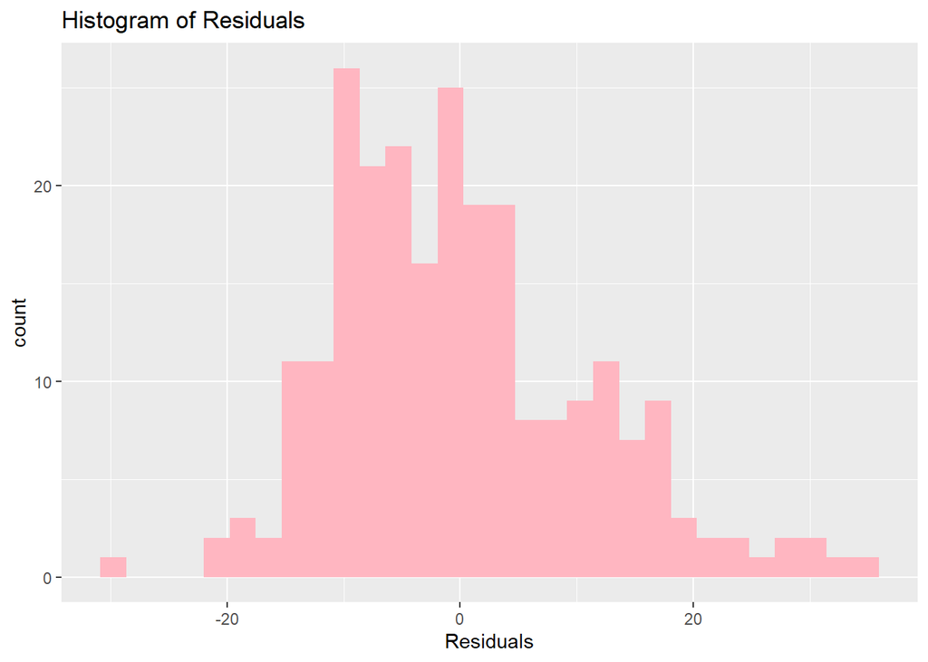

```r
ggplot(data = train_data, aes(x = lastWeekMod2$residuals)) +
    geom_histogram(fill = "lightpink") +
    labs(title = "Histogram of Residuals", x = "Residuals")
```

```r
#get rmse and test R^2
pred_test <- predict(lastWeekMod2, newdata = test_data)
RMSE <- sqrt(mean((test_data$totalDisasters - pred_test)^2))
RMSE
```

```
## [1] 10.95033
```

```r
testR2 <- cor(test_data$totalDisasters, pred_test)^2
testR2
```

```
## [1] 0.1160661
```

Model 1 showed bad multicollinearity so model 2 will have to be different. The multicollinearity problem has been solved by removing average sea pressure, everything is now under 5. The R^2 dropped drastically, unfortunately, but that will likely change when starting to look at interactions and higher order terms.

The histogram of residuals looks pretty normal (maybe the tiniest bit of right skewing) and the scale-location plot also looks pretty normal with no obvious pattern visible meaning the variance should be constant and therefore not have heteroscedasticity. The QQ plot also appears to be pretty well in line with the straight line and there could be potential outliers just looking at the tail of the plot, there’s a few points that stray away but nothing extreme. The residuals vs fitted plot does not show any obvious pattern of curving or U shapes so we can assume this is a linear pattern.

The RSME is a little high and the test R^2 is higher than the training R^2 so there might be some under fitting in my model. This is likely something that will improve with interactions.

**Step 1&2** All plot look normal and linear at first glance but if i look extremely closely I can see a slight squiggle shape in the residuals vs fitted plot as well as the scale location plot. This faint squiggle could suggest a higher order term.

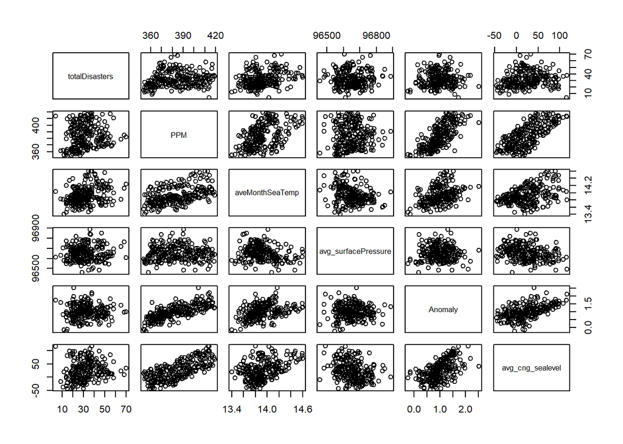

```r
#centering everything
train_data$PPMC <- train_data$PPM - mean(train_data$PPM)

train_data$seaTempC <- train_data$aveMonthSeaTemp - mean(train_data$aveMonthSeaTemp)

train_data$surfacePressC <- train_data$avg_surfacePressure - mean(train_data$avg_surfacePressure)

train_data$surfaceTempCngC <- train_data$Anomaly - mean(train_data$Anomaly)

train_data$sealevelCngC <- train_data$avg_cng_sealevel - mean(train_data$avg_cng_sealevel)

#looking at relationship between every variable
pairs(train_data[, c("totalDisasters", "PPM", "aveMonthSeaTemp",
                     "avg_surfacePressure", "Anomaly", "avg_cng_sealevel")])
```

It appears that there could be very mild curving with all the predictors except for average change in sea level and surface pressure. However the graphs are not very clear so I will try higher order terms on all of predictors.

```r
mod3 <- lm(totalDisasters ~ PPMC + seaTempC + surfaceTempCngC + sealevelCngC + surfacePressC + I(PPMC^2) + I(seaTempC^2) + I(surfaceTempCngC^2) + I(surfacePressC^2) + I(sealevelCngC^2), data = train_data)
summary(mod3)
```

```
##
## Call:
## lm(formula = totalDisasters ~ PPMC + seaTempC + surfaceTempCngC +
##     sealevelCngC + surfacePressC + I(PPMC^2) + I(seaTempC^2) +
##     I(surfaceTempCngC^2) + I(surfacePressC^2) + I(sealevelCngC^2),
##     data = train_data)
##
## Residuals:
##     Min      1Q  Median      3Q     Max
## -26.705  -7.234  -1.488   5.795  31.234
##
## Coefficients:
##                        Estimate Std. Error t value Pr(>|t|)
## (Intercept)           3.633e+01  1.260e+00  28.835  < 2e-16 ***
## PPMC                  1.314e-02  7.382e-02   0.178 0.858876
## seaTempC              1.515e+01  3.778e+00   4.011 8.14e-05 ***
## surfaceTempCngC      -2.610e+00  2.344e+00  -1.114 0.266529
## sealevelCngC          6.030e-02  3.192e-02   1.889 0.060111 .
## surfacePressC         5.785e-03  1.116e-02   0.518 0.604716
## I(PPMC^2)            -7.314e-03  2.681e-03  -2.728 0.006865 **
## I(seaTempC^2)        -2.217e+00  9.958e+00  -0.223 0.824035
## I(surfaceTempCngC^2) -1.402e+00  2.578e+00  -0.544 0.586965
## I(surfacePressC^2)    1.181e-04  9.197e-05   1.285 0.200216
## I(sealevelCngC^2)    -1.817e-03  4.676e-04  -3.885 0.000133 ***
## ---
## Signif. codes:  0 '***' 0.001 '**' 0.01 '*' 0.05 '.' 0.1 ' ' 1
##
## Residual standard error: 10.31 on 233 degrees of freedom
## Multiple R-squared:  0.2313, Adjusted R-squared:  0.1984
## F-statistic: 7.013 on 10 and 233 DF,  p-value: 1.309e-09
```

```r
mod4 <- lm(totalDisasters ~ PPMC + seaTempC + surfaceTempCngC + sealevelCngC + surfacePressC + I(PPMC^3) + I(seaTempC^3) + I(surfaceTempCngC^3) + I(surfacePressC^3) + I(sealevelCngC^3), data = train_data)
summary(mod4)
```

```
##
## Call:
## lm(formula = totalDisasters ~ PPMC + seaTempC + surfaceTempCngC +
##     sealevelCngC + surfacePressC + I(PPMC^3) + I(seaTempC^3) +
##     I(surfaceTempCngC^3) + I(surfacePressC^3) + I(sealevelCngC^3),
##     data = train_data)
##
## Residuals:
##     Min      1Q  Median      3Q     Max
## -25.617  -7.589  -1.160   5.634  34.343
##
## Coefficients:
##                        Estimate Std. Error t value Pr(>|t|)
## (Intercept)           3.185e+01  7.548e-01  42.200  < 2e-16 ***
## PPMC                 -2.994e-01  1.132e-01  -2.646 0.008711 **
## seaTempC              1.828e+01  5.441e+00   3.361 0.000908 ***
## surfaceTempCngC      -4.640e+00  3.219e+00  -1.441 0.150804
## sealevelCngC          1.179e-01  4.674e-02   2.523 0.012311 *
## surfacePressC         1.816e-02  1.710e-02   1.062 0.289429
## I(PPMC^3)             4.426e-04  1.367e-04   3.238 0.001377 **
## I(seaTempC^3)        -1.750e+01  2.257e+01  -0.776 0.438798
## I(surfaceTempCngC^3)  1.322e+00  2.944e+00   0.449 0.653946
## I(surfacePressC^3)    2.271e-07  7.365e-07   0.308 0.758053
## I(sealevelCngC^3)    -1.849e-05  9.867e-06  -1.874 0.062210 .
## ---
## Signif. codes:  0 '***' 0.001 '**' 0.01 '*' 0.05 '.' 0.1 ' ' 1
##
## Residual standard error: 10.8 on 233 degrees of freedom
## Multiple R-squared:  0.1569, Adjusted R-squared:  0.1207
## F-statistic: 4.335 on 10 and 233 DF,  p-value: 1.427e-05
```

Adding higher order terms did help to raise the adjusted R^2 up to 0.198 which is not amazing but a big improvement from 0.08. I can also see that the overall model became more significant and so did individual predictors. Using ^3 actually made things worse so I will continue using ^2 instead. The exception seems to be for PPM where the cubic transformation seemed to make it significant so I will move forward with the cubic only for PPM.

**Step 3** Based on the plots above it seems that every predictor has interaction with every other predictor so I am going to try every possible interaction. This tracks well with how climate works, there are hundreds of factor contributing to natural disasters and most of them are heavily interconnected.

```r
#only interactions with PPM
modInt1 <- lm(totalDisasters ~ PPMC + seaTempC + surfaceTempCngC + sealevelCngC + surfacePressC + I(PPMC^3) + I(seaTempC^2) + I(surfaceTempCngC^2) + I(surfacePressC^2) + I(sealevelCngC^2) + PPMC*surfaceTempCngC + PPMC*seaTempC + PPMC*sealevelCngC + PPMC*surfacePressC, data = train_data)
summary(modInt1)
```

```
##
## Call:
## lm(formula = totalDisasters ~ PPMC + seaTempC + surfaceTempCngC +
##     sealevelCngC + surfacePressC + I(PPMC^3) + I(seaTempC^2) +
##     I(surfaceTempCngC^2) + I(surfacePressC^2) + I(sealevelCngC^2) +
##     PPMC * surfaceTempCngC + PPMC * seaTempC + PPMC * sealevelCngC +
##     PPMC * surfacePressC, data = train_data)
##
## Residuals:
##     Min      1Q  Median      3Q     Max
## -27.660  -6.460  -1.252   5.790  29.773
##
## Coefficients:
##                        Estimate Std. Error t value Pr(>|t|)
## (Intercept)           3.420e+01  1.202e+00  28.459  < 2e-16 ***
## PPMC                 -3.541e-01  1.069e-01  -3.314 0.001068 **
## seaTempC              1.318e+01  3.881e+00   3.395 0.000808 ***
## surfaceTempCngC      -3.864e+00  2.360e+00  -1.637 0.102932
## sealevelCngC          6.641e-02  3.209e-02   2.069 0.039647 *
## surfacePressC         6.273e-03  1.078e-02   0.582 0.561170
## I(PPMC^3)             6.390e-04  1.403e-04   4.554 8.55e-06 ***
## I(seaTempC^2)         1.262e+01  1.496e+01   0.844 0.399689
## I(surfaceTempCngC^2)  6.190e+00  4.354e+00   1.422 0.156498
## I(surfacePressC^2)    1.466e-04  9.033e-05   1.623 0.105961
## I(sealevelCngC^2)    -2.169e-03  9.340e-04  -2.322 0.021128 *
## PPMC:surfaceTempCngC -4.088e-01  1.889e-01  -2.163 0.031540 *
## PPMC:seaTempC        -3.454e-01  2.824e-01  -1.223 0.222575
## PPMC:sealevelCngC     3.410e-04  2.866e-03   0.119 0.905411
## PPMC:surfacePressC   -2.747e-04  5.891e-04  -0.466 0.641370
## ---
## Signif. codes:  0 '***' 0.001 '**' 0.01 '*' 0.05 '.' 0.1 ' ' 1
##
## Residual standard error: 9.957 on 229 degrees of freedom
## Multiple R-squared:  0.2952, Adjusted R-squared:  0.2521
## F-statistic:  6.85 on 14 and 229 DF,  p-value: 1.138e-11
```

```r
#adding in the sea temp interactions, R^2 adj still going up
modInt2 <- lm(totalDisasters ~ PPMC + seaTempC + surfaceTempCngC + sealevelCngC + surfacePressC + I(PPMC^3) + I(seaTempC^2) + I(surfaceTempCngC^2) + I(surfacePressC^2) + I(sealevelCngC^2) + PPMC*surfaceTempCngC + PPMC*seaTempC + PPMC*sealevelCngC + PPMC*surfacePressC + seaTempC*sealevelCngC + seaTempC*surfaceTempCngC + seaTempC*surfacePressC, data = train_data)
summary(modInt2)
```

```
##
## Call:
## lm(formula = totalDisasters ~ PPMC + seaTempC + surfaceTempCngC +
##     sealevelCngC + surfacePressC + I(PPMC^3) + I(seaTempC^2) +
##     I(surfaceTempCngC^2) + I(surfacePressC^2) + I(sealevelCngC^2) +
##     PPMC * surfaceTempCngC + PPMC * seaTempC + PPMC * sealevelCngC +
##     PPMC * surfacePressC + seaTempC * sealevelCngC + seaTempC *
##     surfaceTempCngC + seaTempC * surfacePressC, data = train_data)
##
## Residuals:
##     Min      1Q  Median      3Q     Max
## -25.755  -6.392  -0.900   5.791  30.072
##
## Coefficients:
##                            Estimate Std. Error t value Pr(>|t|)
## (Intercept)               3.421e+01  1.209e+00  28.301  < 2e-16 ***
## PPMC                     -3.598e-01  1.070e-01  -3.364 0.000902 ***
## seaTempC                  9.797e+00  4.909e+00   1.996 0.047141 *
## surfaceTempCngC          -4.784e+00  2.415e+00  -1.981 0.048792 *
## sealevelCngC              8.224e-02  3.363e-02   2.445 0.015240 *
## surfacePressC             8.715e-03  1.085e-02   0.803 0.422822
## I(PPMC^3)                 6.457e-04  1.397e-04   4.622 6.38e-06 ***
## I(seaTempC^2)             1.565e+01  1.505e+01   1.040 0.299416
## I(surfaceTempCngC^2)      8.056e+00  4.465e+00   1.804 0.072506 .
## I(surfacePressC^2)        2.151e-04  9.863e-05   2.181 0.030242 *
## I(sealevelCngC^2)        -2.634e-03  9.860e-04  -2.671 0.008105 **
## PPMC:surfaceTempCngC     -2.913e-01  1.977e-01  -1.474 0.141902
## PPMC:seaTempC            -6.023e-01  4.373e-01  -1.377 0.169783
## PPMC:sealevelCngC        -4.668e-04  2.969e-03  -0.157 0.875187
## PPMC:surfacePressC       -8.624e-04  6.582e-04  -1.310 0.191421
## seaTempC:sealevelCngC     3.620e-01  2.251e-01   1.609 0.109102
## seaTempC:surfaceTempCngC -2.318e+01  1.297e+01  -1.787 0.075216 .
## seaTempC:surfacePressC    1.085e-01  5.353e-02   2.026 0.043890 *
## ---
## Signif. codes:  0 '***' 0.001 '**' 0.01 '*' 0.05 '.' 0.1 ' ' 1
##
## Residual standard error: 9.863 on 226 degrees of freedom
## Multiple R-squared:  0.3174, Adjusted R-squared:  0.2661
## F-statistic: 6.182 on 17 and 226 DF,  p-value: 9.056e-12
```

```r
#adding in surface temperature change interactions. Adjusted R^2 continues to go up so I will continue to try more terms
modInt3 <- lm(totalDisasters ~
                PPMC + seaTempC + surfaceTempCngC + sealevelCngC + surfacePressC
              + I(PPMC^3) + I(seaTempC^2) + I(surfaceTempCngC^2)
              + I(surfacePressC^2) + I(sealevelCngC^2) + (PPMC*surfaceTempCngC)
              + (PPMC*seaTempC) + (PPMC*sealevelCngC) + (PPMC*surfacePressC)
              + (seaTempC*sealevelCngC) + (seaTempC*surfaceTempCngC)
              + (seaTempC*surfacePressC) + (surfaceTempCngC*sealevelCngC)
              + (surfaceTempCngC*surfacePressC),
              data = train_data)
summary(modInt3)
```

```
##
## Call:
## lm(formula = totalDisasters ~ PPMC + seaTempC + surfaceTempCngC +
##     sealevelCngC + surfacePressC + I(PPMC^3) + I(seaTempC^2) +
##     I(surfaceTempCngC^2) + I(surfacePressC^2) + I(sealevelCngC^2) +
##     (PPMC * surfaceTempCngC) + (PPMC * seaTempC) + (PPMC * sealevelCngC) +
##     (PPMC * surfacePressC) + (seaTempC * sealevelCngC) + (seaTempC *
##     surfaceTempCngC) + (seaTempC * surfacePressC) + (surfaceTempCngC *
##     sealevelCngC) + (surfaceTempCngC * surfacePressC), data = train_data)
##
## Residuals:
##      Min       1Q   Median       3Q      Max
## -26.7951  -6.2109  -0.8752   5.0258  28.9948
##
## Coefficients:
##                                 Estimate Std. Error t value Pr(>|t|)
## (Intercept)                    3.533e+01  1.229e+00  28.736  < 2e-16 ***
## PPMC                          -3.959e-01  1.054e-01  -3.756 0.000220 ***
## seaTempC                       1.284e+01  4.973e+00   2.581 0.010488 *
## surfaceTempCngC               -2.437e+00  2.462e+00  -0.990 0.323287
## sealevelCngC                   5.504e-02  3.437e-02   1.601 0.110761
## surfacePressC                  9.677e-03  1.063e-02   0.910 0.363751
## I(PPMC^3)                      6.927e-04  1.377e-04   5.032 9.96e-07 ***
## I(seaTempC^2)                  1.524e+01  1.483e+01   1.028 0.305216
## I(surfaceTempCngC^2)           4.345e+00  4.506e+00   0.964 0.335968
## I(surfacePressC^2)             1.967e-04  9.671e-05   2.034 0.043139 *
## I(sealevelCngC^2)             -3.736e-03  1.026e-03  -3.642 0.000336 ***
## PPMC:surfaceTempCngC          -6.092e-01  2.186e-01  -2.787 0.005779 **
## PPMC:seaTempC                 -2.224e-01  4.664e-01  -0.477 0.633898
## PPMC:sealevelCngC             -1.632e-03  2.927e-03  -0.558 0.577679
## PPMC:surfacePressC            -1.851e-03  9.335e-04  -1.983 0.048564 *
## seaTempC:sealevelCngC          1.098e-01  2.348e-01   0.468 0.640566
## seaTempC:surfaceTempCngC      -9.717e+00  1.335e+01  -0.728 0.467400
## seaTempC:surfacePressC         7.931e-02  5.323e-02   1.490 0.137653
## surfaceTempCngC:sealevelCngC   3.349e-01  1.035e-01   3.235 0.001400 **
## surfaceTempCngC:surfacePressC  6.924e-02  3.234e-02   2.141 0.033343 *
## ---
## Signif. codes:  0 '***' 0.001 '**' 0.01 '*' 0.05 '.' 0.1 ' ' 1
##
## Residual standard error: 9.655 on 224 degrees of freedom
## Multiple R-squared:  0.3518, Adjusted R-squared:  0.2968
## F-statistic: 6.398 on 19 and 224 DF,  p-value: 4.11e-13
```

```r
#added in the last interaction and adjusted R^2 actually went up again, so this is the best model so far
modInt4 <- lm(totalDisasters ~
                PPMC + seaTempC + surfaceTempCngC + sealevelCngC + surfacePressC
              + I(PPMC^3) + I(seaTempC^2) + I(surfaceTempCngC^2)
              + I(surfacePressC^2) + I(sealevelCngC^2) + (PPMC*surfaceTempCngC)
              + (PPMC*seaTempC) + (PPMC*sealevelCngC) + (PPMC*surfacePressC)
              + (seaTempC*sealevelCngC) + (seaTempC*surfaceTempCngC)
              + (seaTempC*surfacePressC) + (surfaceTempCngC*sealevelCngC)
              + (surfaceTempCngC*surfacePressC) + (sealevelCngC*surfacePressC),
              data = train_data)
summary(modInt4)
```

```
##
## Call:
## lm(formula = totalDisasters ~ PPMC + seaTempC + surfaceTempCngC +
##     sealevelCngC + surfacePressC + I(PPMC^3) + I(seaTempC^2) +
##     I(surfaceTempCngC^2) + I(surfacePressC^2) + I(sealevelCngC^2) +
##     (PPMC * surfaceTempCngC) + (PPMC * seaTempC) + (PPMC * sealevelCngC) +
##     (PPMC * surfacePressC) + (seaTempC * sealevelCngC) + (seaTempC *
##     surfaceTempCngC) + (seaTempC * surfacePressC) + (surfaceTempCngC *
##     sealevelCngC) + (surfaceTempCngC * surfacePressC) + (sealevelCngC *
##     surfacePressC), data = train_data)
##
## Residuals:
##     Min      1Q  Median      3Q     Max
## -26.594  -6.464  -0.819   4.850  29.053
##
## Coefficients:
##                                 Estimate Std. Error t value Pr(>|t|)
## (Intercept)                    3.543e+01  1.226e+00  28.898  < 2e-16 ***
## PPMC                          -4.062e-01  1.052e-01  -3.863 0.000147 ***
## seaTempC                       1.269e+01  4.954e+00   2.561 0.011100 *
## surfaceTempCngC               -2.322e+00  2.453e+00  -0.947 0.344774
## sealevelCngC                   5.626e-02  3.424e-02   1.643 0.101801
## surfacePressC                  6.173e-03  1.080e-02   0.572 0.568097
## I(PPMC^3)                      7.093e-04  1.375e-04   5.159 5.47e-07 ***
## I(seaTempC^2)                  1.526e+01  1.477e+01   1.033 0.302621
## I(surfaceTempCngC^2)           3.739e+00  4.503e+00   0.830 0.407184
## I(surfacePressC^2)             2.828e-04  1.093e-04   2.588 0.010285 *
## I(sealevelCngC^2)             -2.983e-03  1.117e-03  -2.671 0.008118 **
## PPMC:surfaceTempCngC          -5.473e-01  2.209e-01  -2.478 0.013958 *
## PPMC:seaTempC                 -3.174e-01  4.680e-01  -0.678 0.498354
## PPMC:sealevelCngC             -3.805e-03  3.193e-03  -1.192 0.234616
## PPMC:surfacePressC            -2.975e-03  1.148e-03  -2.592 0.010186 *
## seaTempC:sealevelCngC          1.940e-01  2.392e-01   0.811 0.418390
## seaTempC:surfaceTempCngC      -1.027e+01  1.330e+01  -0.772 0.440904
## seaTempC:surfacePressC         1.105e-01  5.622e-02   1.966 0.050590 .
## surfaceTempCngC:sealevelCngC   3.191e-01  1.035e-01   3.082 0.002317 **
## surfaceTempCngC:surfacePressC  6.578e-02  3.228e-02   2.038 0.042725 *
## sealevelCngC:surfacePressC     7.962e-04  4.770e-04   1.669 0.096531 .
## ---
## Signif. codes:  0 '***' 0.001 '**' 0.01 '*' 0.05 '.' 0.1 ' ' 1
##
## Residual standard error: 9.616 on 223 degrees of freedom
## Multiple R-squared:  0.3598, Adjusted R-squared:  0.3024
## F-statistic: 6.266 on 20 and 223 DF,  p-value: 3.249e-13
```

```r
#removing the non significant values and trying out higher order interactions
#this caused the adjusted R^2 to go down so then model 4 is the best one
#none of the higher order interactions are significant so I will exclude them
modInt5 <- lm(totalDisasters ~
                PPMC + seaTempC + surfaceTempCngC + sealevelCngC + surfacePressC
              + I(PPMC^3) + I(seaTempC^2) + I(surfaceTempCngC^2)
              + I(surfacePressC^2) + I(sealevelCngC^2) + (PPMC*surfaceTempCngC)
              + (PPMC*sealevelCngC) + (PPMC*surfacePressC)
              + (seaTempC*sealevelCngC) + (seaTempC*surfaceTempCngC)
              + (surfaceTempCngC*sealevelCngC) + (surfaceTempCngC*surfacePressC)
              + (sealevelCngC*surfacePressC) + (I(PPMC^3)*surfaceTempCngC)
              + (I(PPMC^3)*surfacePressC) + (I(PPMC^3)*sealevelCngC)
              + (I(seaTempC^2)*surfacePressC) + (I(seaTempC^2)*sealevelCngC),
              data = train_data)
summary(modInt5)
```

```
##
## Call:
## lm(formula = totalDisasters ~ PPMC + seaTempC + surfaceTempCngC +
##     sealevelCngC + surfacePressC + I(PPMC^3) + I(seaTempC^2) +
##     I(surfaceTempCngC^2) + I(surfacePressC^2) + I(sealevelCngC^2) +
##     (PPMC * surfaceTempCngC) + (PPMC * sealevelCngC) + (PPMC *
##     surfacePressC) + (seaTempC * sealevelCngC) + (seaTempC *
##     surfaceTempCngC) + (surfaceTempCngC * sealevelCngC) + (surfaceTempCngC *
##     surfacePressC) + (sealevelCngC * surfacePressC) + (I(PPMC^3) *
##     surfaceTempCngC) + (I(PPMC^3) * surfacePressC) + (I(PPMC^3) *
##     sealevelCngC) + (I(seaTempC^2) * surfacePressC) + (I(seaTempC^2) *
##     sealevelCngC), data = train_data)
##
## Residuals:
##     Min      1Q  Median      3Q     Max
## -27.580  -6.259  -1.011   4.874  29.505
##
## Coefficients:
##                                 Estimate Std. Error t value Pr(>|t|)
## (Intercept)                    3.481e+01  1.372e+00  25.377  < 2e-16 ***
## PPMC                          -3.993e-01  1.105e-01  -3.612 0.000376 ***
## seaTempC                       1.220e+01  4.400e+00   2.772 0.006048 **
## surfaceTempCngC               -2.412e+00  2.503e+00  -0.964 0.336322
## sealevelCngC                   5.514e-02  3.594e-02   1.534 0.126406
## surfacePressC                  1.235e-02  1.408e-02   0.877 0.381616
## I(PPMC^3)                      7.268e-04  1.584e-04   4.589 7.48e-06 ***
## I(seaTempC^2)                  1.489e+01  1.726e+01   0.862 0.389381
## I(surfaceTempCngC^2)           3.675e+00  4.589e+00   0.801 0.424087
## I(surfacePressC^2)             1.782e-04  9.731e-05   1.831 0.068415 .
## I(sealevelCngC^2)             -3.142e-03  1.174e-03  -2.675 0.008024 **
## PPMC:surfaceTempCngC          -4.763e-01  3.279e-01  -1.453 0.147773
## PPMC:sealevelCngC             -5.567e-04  5.029e-03  -0.111 0.911964
## PPMC:surfacePressC            -7.103e-04  1.604e-03  -0.443 0.658289
## seaTempC:sealevelCngC          2.636e-02  1.894e-01   0.139 0.889407
## seaTempC:surfaceTempCngC      -1.160e+01  1.379e+01  -0.841 0.401136
## surfaceTempCngC:sealevelCngC   3.203e-01  1.041e-01   3.076 0.002362 **
## surfaceTempCngC:surfacePressC  6.725e-02  3.364e-02   1.999 0.046816 *
## sealevelCngC:surfacePressC     4.886e-04  5.074e-04   0.963 0.336539
## surfaceTempCngC:I(PPMC^3)     -8.559e-05  3.424e-04  -0.250 0.802854
## surfacePressC:I(PPMC^3)       -2.018e-06  2.073e-06  -0.973 0.331382
## sealevelCngC:I(PPMC^3)        -3.328e-06  5.275e-06  -0.631 0.528769
## surfacePressC:I(seaTempC^2)   -7.034e-02  1.506e-01  -0.467 0.640958
## sealevelCngC:I(seaTempC^2)    -8.415e-02  3.705e-01  -0.227 0.820550
## ---
## Signif. codes:  0 '***' 0.001 '**' 0.01 '*' 0.05 '.' 0.1 ' ' 1
##
## Residual standard error: 9.728 on 220 degrees of freedom
## Multiple R-squared:  0.3536, Adjusted R-squared:  0.2861
## F-statistic: 5.233 on 23 and 220 DF,  p-value: 1.209e-11
```

There does not seem to be any issues with multicollinearity.

```r
car::vif(modInt4, type = "predictor")
```

```
## GVIFs computed for predictors
```

```
##                 GVIF Df GVIF^(1/(2*Df))
## PPMC               1 20               1
## seaTempC           1 20               1
## surfaceTempCngC    1 20               1
## sealevelCngC       1 20               1
## surfacePressC      1 20               1
##                                                                    Interacts With
## PPMC            I(PPMC^3), surfaceTempCngC, seaTempC, sealevelCngC, surfacePressC
## seaTempC        I(seaTempC^2), PPMC, sealevelCngC, surfaceTempCngC, surfacePressC
## surfaceTempCngC I(surfaceTempCngC^2), PPMC, seaTempC, sealevelCngC, surfacePressC
## sealevelCngC    I(sealevelCngC^2), PPMC, seaTempC, surfaceTempCngC, surfacePressC
## surfacePressC   I(surfacePressC^2), PPMC, seaTempC, surfaceTempCngC, sealevelCngC
##                 Other Predictors
## PPMC                        --
## seaTempC                    --
## surfaceTempCngC             --
## sealevelCngC                --
## surfacePressC               --
```

**Step 5 Part 1** The curve seems to peak at lambda = 0.4.

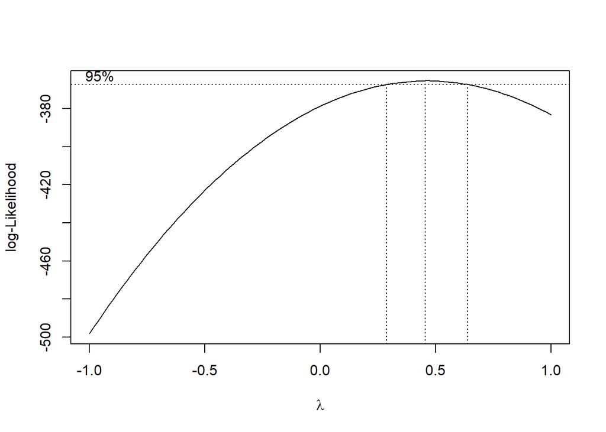

```r
library(MASS)
boxcox(modInt4, lambda = seq(-1, 1))
```

After the Y transformation the adjusted R^2 went up to 32.34 which is a good improvement.

```r
train_data$disaster.4 <- train_data$totalDisasters^0.4
modTransform <- lm(disaster.4 ~
                PPMC + seaTempC + surfaceTempCngC + sealevelCngC + surfacePressC
              + I(PPMC^3) + I(seaTempC^2) + I(surfaceTempCngC^2)
              + I(surfacePressC^2) + I(sealevelCngC^2) + (PPMC*surfaceTempCngC)
              + (PPMC*seaTempC) + (PPMC*sealevelCngC) + (PPMC*surfacePressC)
              + (seaTempC*sealevelCngC) + (seaTempC*surfaceTempCngC)
              + (seaTempC*surfacePressC) + (surfaceTempCngC*sealevelCngC)
              + (surfaceTempCngC*surfacePressC) + (sealevelCngC*surfacePressC),
              data = train_data)
summary(modTransform)
```

```
##
## Call:
## lm(formula = disaster.4 ~ PPMC + seaTempC + surfaceTempCngC +
##     sealevelCngC + surfacePressC + I(PPMC^3) + I(seaTempC^2) +
##     I(surfaceTempCngC^2) + I(surfacePressC^2) + I(sealevelCngC^2) +
##     (PPMC * surfaceTempCngC) + (PPMC * seaTempC) + (PPMC * sealevelCngC) +
##     (PPMC * surfacePressC) + (seaTempC * sealevelCngC) + (seaTempC *
##     surfaceTempCngC) + (seaTempC * surfacePressC) + (surfaceTempCngC *
##     sealevelCngC) + (surfaceTempCngC * surfacePressC) + (sealevelCngC *
##     surfacePressC), data = train_data)
##
## Residuals:
##      Min       1Q   Median       3Q      Max
## -1.61939 -0.30692 -0.01154  0.27849  1.13539
##
## Coefficients:
##                                 Estimate Std. Error t value Pr(>|t|)
## (Intercept)                    4.117e+00  6.094e-02  67.564  < 2e-16 ***
## PPMC                          -1.924e-02  5.226e-03  -3.681 0.000292 ***
## seaTempC                       6.057e-01  2.462e-01   2.460 0.014657 *
## surfaceTempCngC               -1.229e-01  1.219e-01  -1.008 0.314425
## sealevelCngC                   2.525e-03  1.702e-03   1.484 0.139280
## surfacePressC                  2.139e-04  5.366e-04   0.399 0.690481
## I(PPMC^3)                      3.581e-05  6.832e-06   5.242 3.69e-07 ***
## I(seaTempC^2)                  7.981e-01  7.342e-01   1.087 0.278182
## I(surfaceTempCngC^2)           1.024e-01  2.238e-01   0.457 0.647761
## I(surfacePressC^2)             1.572e-05  5.431e-06   2.894 0.004181 **
## I(sealevelCngC^2)             -1.432e-04  5.551e-05  -2.579 0.010537 *
## PPMC:surfaceTempCngC          -2.308e-02  1.098e-02  -2.102 0.036642 *
## PPMC:seaTempC                 -1.442e-02  2.326e-02  -0.620 0.535898
## PPMC:sealevelCngC             -2.668e-04  1.587e-04  -1.681 0.094170 .
## PPMC:surfacePressC            -1.473e-04  5.705e-05  -2.582 0.010465 *
## seaTempC:sealevelCngC          1.126e-02  1.189e-02   0.947 0.344590
## seaTempC:surfaceTempCngC      -6.828e-01  6.610e-01  -1.033 0.302698
## seaTempC:surfacePressC         5.647e-03  2.794e-03   2.021 0.044461 *
## surfaceTempCngC:sealevelCngC   1.627e-02  5.146e-03   3.162 0.001785 **
## surfaceTempCngC:surfacePressC  2.708e-03  1.604e-03   1.688 0.092805 .
## sealevelCngC:surfacePressC     4.533e-05  2.371e-05   1.912 0.057141 .
## ---
## Signif. codes:  0 '***' 0.001 '**' 0.01 '*' 0.05 '.' 0.1 ' ' 1
##
## Residual standard error: 0.4779 on 223 degrees of freedom
## Multiple R-squared:  0.3791, Adjusted R-squared:  0.3234
## F-statistic: 6.808 on 20 and 223 DF,  p-value: 1.686e-14
```

**Step 5 Part 2**

I can see the worlds slightest curving for ppmc and maybe sea temp and sea elvel change however, this was already addressed with using higher order terms which is why I think further transformation is not nesscary in this case.

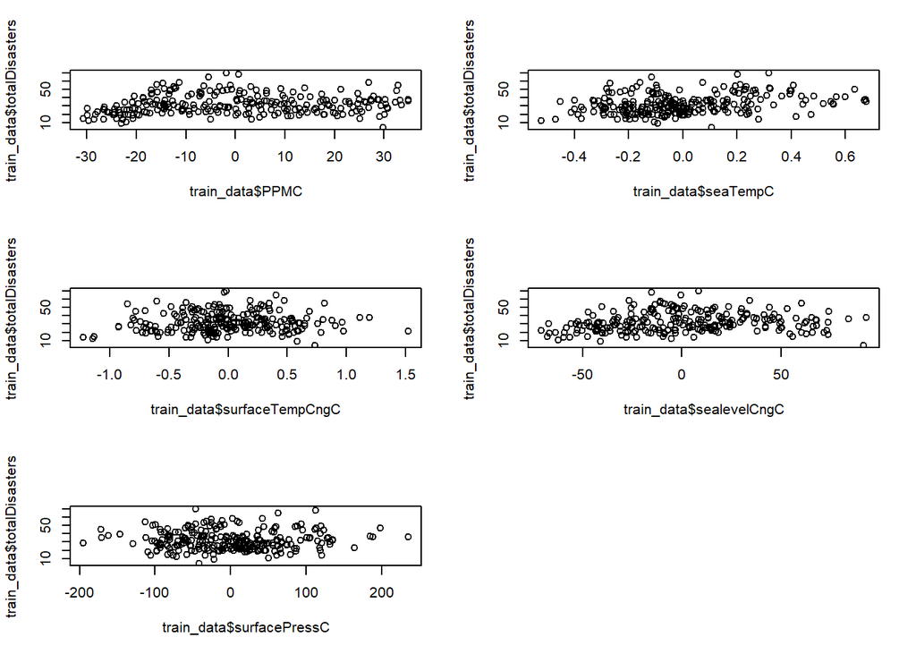

```r
#looking at scatter plots for curving

par(mfrow = c(3, 2))
plot(train_data$PPMC, train_data$totalDisasters)
plot(train_data$seaTempC, train_data$totalDisasters)
plot(train_data$surfaceTempCngC, train_data$totalDisasters)
plot(train_data$sealevelCngC, train_data$totalDisasters)
plot(train_data$surfacePressC, train_data$totalDisasters)
```

**Step 5, part 3**

I decided to do do a Y transformation because the boxcox plot showed that improvement was possible as the peak was at lambda = 0.4 and it went above the 95% line. I did not do any further X transformations because the scatter plots looked fine and any slight curving was addressed through the higher order terms. All of the plots look linear at first glance but have very slight curving when looking closer, which is what the higher order terms fixed. Before, the R^2 adjusted was 30 and afterwards the R^2 adjusted was 32, this is a good amount when taking into account that our data set only looks at a few factors of climate disasters when it should have hundreds of variables. I included a side by side before and after of the Y transformation.

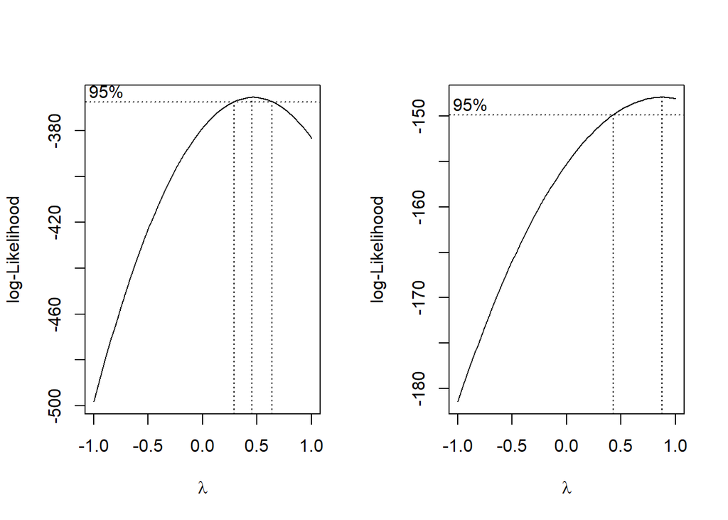

```r
par(mfrow = c(1, 2))
boxcox(modInt4, lambda = seq(-1, 1))
boxcox(modTransform, lambda = seq(-1, 1))
```

**Step 6**

```r
#reduced model
modRefined <- lm(disaster.4 ~
                PPMC + seaTempC + sealevelCngC + I(PPMC^3)
              + I(surfacePressC^2) + I(sealevelCngC^2) + (PPMC*surfaceTempCngC)
              + (PPMC*sealevelCngC) + (PPMC*surfacePressC)
              + (seaTempC*surfacePressC) + (surfaceTempCngC*sealevelCngC)
              + (surfaceTempCngC*surfacePressC) + (sealevelCngC*surfacePressC),
              data = train_data)
summary(modRefined)
```

```
##
## Call:
## lm(formula = disaster.4 ~ PPMC + seaTempC + sealevelCngC + I(PPMC^3) +
##     I(surfacePressC^2) + I(sealevelCngC^2) + (PPMC * surfaceTempCngC) +
##     (PPMC * sealevelCngC) + (PPMC * surfacePressC) + (seaTempC *
##     surfacePressC) + (surfaceTempCngC * sealevelCngC) + (surfaceTempCngC *
##     surfacePressC) + (sealevelCngC * surfacePressC), data = train_data)
##
## Residuals:
##      Min       1Q   Median       3Q      Max
## -1.68732 -0.31307 -0.01013  0.25356  1.17256
##
## Coefficients:
##                                 Estimate Std. Error t value Pr(>|t|)
## (Intercept)                    4.162e+00  5.176e-02  80.422  < 2e-16 ***
## PPMC                          -1.964e-02  5.066e-03  -3.877 0.000138 ***
## seaTempC                       8.544e-01  1.746e-01   4.893 1.88e-06 ***
## sealevelCngC                   2.657e-03  1.408e-03   1.887 0.060428 .
## I(PPMC^3)                      3.473e-05  6.624e-06   5.244 3.59e-07 ***
## I(surfacePressC^2)             1.488e-05  5.032e-06   2.958 0.003425 **
## I(sealevelCngC^2)             -1.454e-04  5.458e-05  -2.663 0.008288 **
## surfaceTempCngC               -1.186e-01  1.066e-01  -1.113 0.266752
## surfacePressC                  1.823e-04  5.225e-04   0.349 0.727472
## PPMC:surfaceTempCngC          -2.813e-02  6.349e-03  -4.431 1.46e-05 ***
## PPMC:sealevelCngC             -2.342e-04  1.449e-04  -1.616 0.107382
## PPMC:surfacePressC            -1.422e-04  5.347e-05  -2.660 0.008368 **
## seaTempC:surfacePressC         4.292e-03  2.356e-03   1.821 0.069876 .
## sealevelCngC:surfaceTempCngC   1.821e-02  4.382e-03   4.155 4.59e-05 ***
## surfaceTempCngC:surfacePressC  3.058e-03  1.528e-03   2.001 0.046556 *
## sealevelCngC:surfacePressC     4.059e-05  2.286e-05   1.776 0.077119 .
## ---
## Signif. codes:  0 '***' 0.001 '**' 0.01 '*' 0.05 '.' 0.1 ' ' 1
##
## Residual standard error: 0.4759 on 228 degrees of freedom
## Multiple R-squared:  0.3705, Adjusted R-squared:  0.3291
## F-statistic: 8.946 on 15 and 228 DF,  p-value: 3.267e-16
```

```r
car::vif(modRefined, type = "predictor")
```

```
## GVIFs computed for predictors
```

```
##                     GVIF Df GVIF^(1/(2*Df))
## PPMC            2.488351 13        1.035684
## seaTempC        3.358737  4        1.163515
## sealevelCngC    2.488351 13        1.035684
## surfacePressC   1.000000 15        1.000000
## surfaceTempCngC 2.488351 13        1.035684
##                                                               Interacts With
## PPMC                 I(PPMC^3), surfaceTempCngC, sealevelCngC, surfacePressC
## seaTempC                                                       surfacePressC
## sealevelCngC         I(sealevelCngC^2), PPMC, surfaceTempCngC, surfacePressC
## surfacePressC   surfacePressC, PPMC, seaTempC, surfaceTempCngC, sealevelCngC
## surfaceTempCngC                            PPMC, sealevelCngC, surfacePressC
##                                    Other Predictors
## PPMC                                       seaTempC
## seaTempC        PPMC, sealevelCngC, surfaceTempCngC
## sealevelCngC                               seaTempC
## surfacePressC                                  --
## surfaceTempCngC                            seaTempC
```

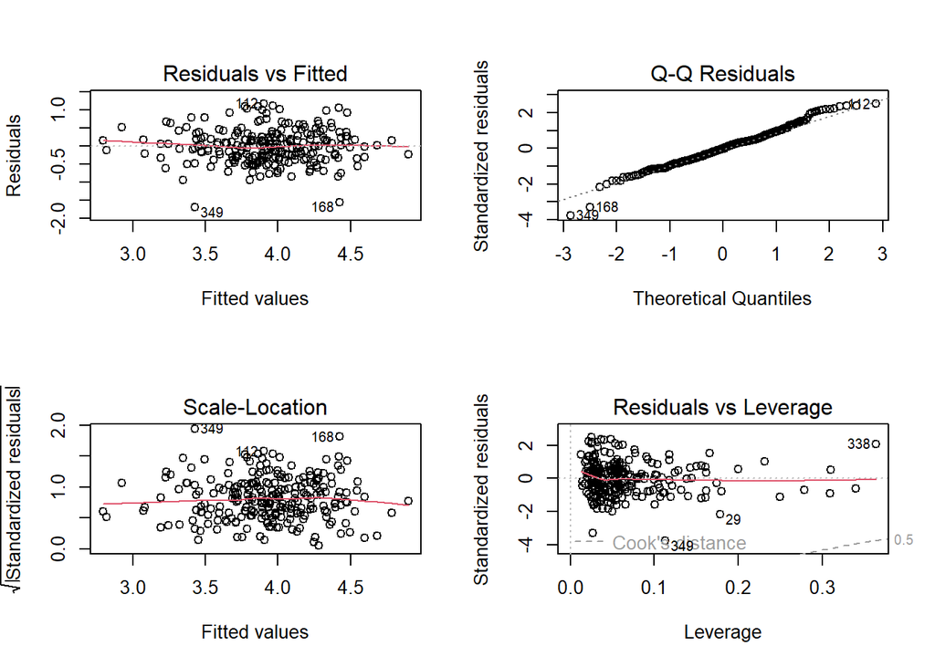

```r
par(mfrow = c(2,2))
plot(modRefined)
```

**Step 7**

```r
test_data$PPMC <- test_data$PPM - mean(train_data$PPM)
test_data$seaTempC <- test_data$aveMonthSeaTemp - mean(train_data$aveMonthSeaTemp)
test_data$surfacePressC <- test_data$avg_surfacePressure - mean(train_data$avg_surfacePressure)
test_data$surfaceTempCngC <- test_data$Anomaly - mean(train_data$Anomaly)
test_data$sealevelCngC <- test_data$avg_cng_sealevel - mean(train_data$avg_cng_sealevel)

pred_test <- predict(modRefined, newdata = test_data)
pred_test_adj <- pred_test^(1/.4)
RMSE <- sqrt(mean((test_data$totalDisasters - pred_test_adj)^2))

RMSE
```

```
## [1] 9.377723
```

```r
modRefined <- lm(totalDisasters^0.4 ~
                PPMC + seaTempC + sealevelCngC + I(PPMC^3)
              + I(surfacePressC^2) + I(sealevelCngC^2) + (PPMC*surfaceTempCngC)
              + (PPMC*sealevelCngC) + (PPMC*surfacePressC)
              + (seaTempC*surfacePressC) + (surfaceTempCngC*sealevelCngC)
              + (surfaceTempCngC*surfacePressC) + (sealevelCngC*surfacePressC),
              data = test_data)
summary(modRefined)
```

```
##
## Call:
## lm(formula = totalDisasters^0.4 ~ PPMC + seaTempC + sealevelCngC +
##     I(PPMC^3) + I(surfacePressC^2) + I(sealevelCngC^2) + (PPMC *
##     surfaceTempCngC) + (PPMC * sealevelCngC) + (PPMC * surfacePressC) +
##     (seaTempC * surfacePressC) + (surfaceTempCngC * sealevelCngC) +
##     (surfaceTempCngC * surfacePressC) + (sealevelCngC * surfacePressC),
##     data = test_data)
##
## Residuals:
##      Min       1Q   Median       3Q      Max
## -0.94862 -0.28136  0.00049  0.30660  1.04073
##
## Coefficients:
##                                 Estimate Std. Error t value Pr(>|t|)
## (Intercept)                    4.089e+00  8.728e-02  46.848  < 2e-16 ***
## PPMC                          -3.033e-02  7.679e-03  -3.949 0.000156 ***
## seaTempC                       9.775e-01  2.979e-01   3.282 0.001475 **
## sealevelCngC                   2.054e-03  2.332e-03   0.881 0.380897
## I(PPMC^3)                      3.441e-05  1.052e-05   3.269 0.001534 **
## I(surfacePressC^2)             2.458e-05  1.267e-05   1.939 0.055640 .
## I(sealevelCngC^2)             -2.854e-04  1.025e-04  -2.784 0.006564 **
## surfaceTempCngC                1.636e-01  1.831e-01   0.893 0.374039
## surfacePressC                  3.544e-05  9.428e-04   0.038 0.970098
## PPMC:surfaceTempCngC          -2.921e-02  1.099e-02  -2.657 0.009344 **
## PPMC:sealevelCngC              1.666e-04  2.498e-04   0.667 0.506663
## PPMC:surfacePressC            -2.082e-04  1.035e-04  -2.012 0.047253 *
## seaTempC:surfacePressC        -2.408e-03  4.810e-03  -0.501 0.617846
## sealevelCngC:surfaceTempCngC   1.577e-02  7.240e-03   2.178 0.032013 *
## surfaceTempCngC:surfacePressC  5.916e-03  2.686e-03   2.203 0.030202 *
## sealevelCngC:surfacePressC     3.141e-05  4.643e-05   0.676 0.500522
## ---
## Signif. codes:  0 '***' 0.001 '**' 0.01 '*' 0.05 '.' 0.1 ' ' 1
##
## Residual standard error: 0.4717 on 89 degrees of freedom
## Multiple R-squared:  0.4731, Adjusted R-squared:  0.3844
## F-statistic: 5.329 on 15 and 89 DF,  p-value: 1.754e-07
```